# Lecture 13: Hypothesis testing

Data Analysis for Psychology in R 1

Tom Booth

Click for slides

## Today

- Introduce hypothesis testing
- Discuss the different elements of a hypothesis test
- Particular focus on the idea of a null distribution.

## Learning objectives

- Understand the structure of a hypothesis test.
- Develop familiarity with key terminology of hypothesis testing.

## Example

- Suppose Umberto and I taught dapR to two separate cohorts of students.
  - Umberto taught one class
  - I taught the other
- We measure how well each student does with the course grade.
- We want to know if Umberto or I are the better teacher.
  - So, is there a difference in the average grade of Umberto’s class vs my class.

## Data

```r
class <- tibble(
    ID = paste(rep("ID", 300), 1:300, sep = ""),
    grade = round(rnorm(300, 55, 15),0),
    teacher = as_factor(sample(c("Umberto", "Tom"), 300, replace = T, prob = (c(.5,.5))))
)
head(class)
# A tibble: 6 x 3
  ID    grade teacher
  <chr> <dbl> <fct>
1 ID1      46 Umberto
2 ID2      64 Umberto
3 ID3      27 Umberto
4 ID4      43 Umberto
5 ID5      62 Tom
6 ID6      53 Tom
```

## The ideal

- We have some exact predictions to compare
  - Person 1: There will be a 5 point difference in grades.
  - Person 2: There will be a 15 point difference in grades.
- But what happens if the difference is 8 points?
  - Neither is right
  - But the grades still differ

## The reality

- We have a sample of data
- From which we calculate a statistic
- And we need some way to make a decision about the value of that statistic.
  - Enter hypothesis testing.

## Questions vs hypotheses

- Research question.
  - Statement on the expected relations between variables of interest.
  - Can be “messy” (not precisely stated)
- Statistical hypothesis
  - Precise mathematical statement
  - Testable!

## Hypotheses

- The typically applied hypothesis testing framework in psychology has two hypotheses.
  - $H_0$ : the null hypothesis
  - $H_1$ : the alternative hypothesis
- Note the similarity to our ideal:
  - $H_0$ : Person 1
  - $H_1$ : Person 2
- But we said this was not the reality…so what is different?

## Defining H0

- Assume that Umberto and I were equally good teachers.
- And that there was nothing systematic about how students were assigned to classes.
  - So the students were essentially random samples of the population of students.
- What would we expect the difference in average score of classes to be?
- By chance, $\Delta\bar{x} = 0$.
- This is perhaps the simplest way to think of defining H0.
  - What would the result be if only chance were at play?
- So if I were trying to guess the card you drew from a deck, by chance I would get this right $\frac{1}{52}$ times.
  - If this was my study, my null would be the proportion $\frac{1}{52} = 0.019$
- $H_0$ is a very specific hypothesis.
- It states that the population value of a statistic is **equal** to specific value.

## Defining H1

- $H_1$ is the opposing position to $H_0$.
  - Specifying $H_1$ is where we see the difference to the ideal case.
- $H_1$ claims “some other state of the world” is true.
  - But is broader with respect to what this might be.
- $H_1$ can be **one-sided** or **two-sided**
- Two-sided:
  - The difference in grades $\neq 0$
- One-sided
  - The difference in grades is $< 0$
  - The difference in grades is $> 0$
  - These correspond a belief in who would be a better teacher.

## Test Statistic

- A test statistic is a calculation that provides a value in keeping with our research question.
  - It is calculated on a sample of data.
- We have been implicitly talking about the test statistic for our example.
  - The difference in means.
  - Aside: We are currently talking about a raw difference in means.
  - Formally the test statistic here is a $t$-statistic (we will talk about this in full in a couple of weeks)

## Point-estimates

- A point estimate, as we have discussed, is simply a value of a statistic calculated in a sample.

```r
class %>%
    group_by(teacher) %>%
    summarise(
        mean = round(mean(grade),1)
        )
# A tibble: 2 x 2
  teacher  mean
  <fct>   <dbl>
1 Umberto  54.8
2 Tom      54.4
```

- $\Delta\bar{x}$ = 0.5

## Null Distribution

- A key point about a test statistic is that it must have a calculable sampling distribution under the null.
  - Ooft, sounds heavy!
  - It is, but we have covered all we need to know.
- In week 11 we saw exactly how we can construct sampling distributions.
- This is no different.
  - **IF** the null is true, what would the variation around the null hypothesis look like.

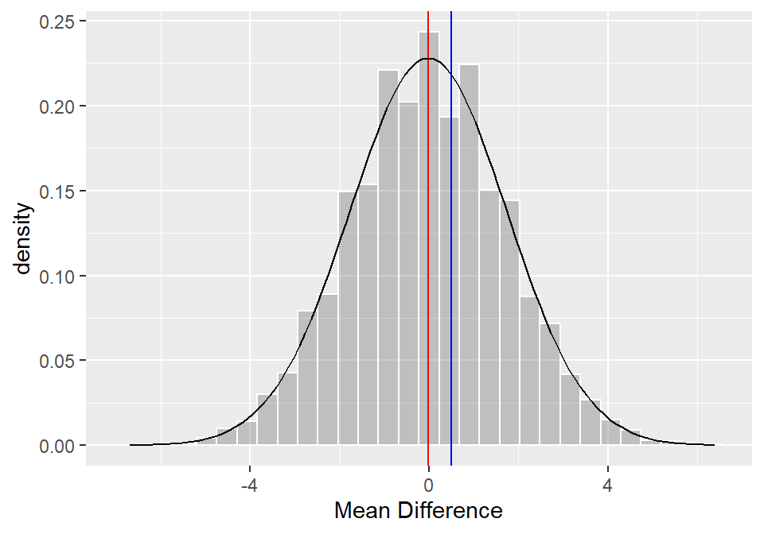

## Probability and the null

- To recap again, the area under the curve provides us with probability.
- We can calculate the probability at the point where the blue line (our sample estimate), is on our x-axis.
- This probability is what is referred to as the $p$-value.

## p-value

```r
dif %>%
    summarise(
        pvalue = sum(delta >= obs_delta)/n()
    )
# A tibble: 1 x 1
  pvalue
   <dbl>
1  0.395
```

- The $p$-value represents the chance of obtaining a statistic as extreme or more extreme than the observed statistic, if the null hypothesis were true.
- This represents the area under the curve to the right of the blue line.
  - The area furthest from the null (red line)

## Significance Level

- So we know the exact probability of our point estimate, given the sampling distribution for the null.
- How can we evaluate it?
- We do this by assigning a significance level, or $\alpha$ level.
  - $\alpha$ is cut-off point.
  - If our $p$-value is $< \alpha$ we make one decision.
  - If our $p$-value is $\geq \alpha$ we make another decision
- We typically use $\alpha$ = 0.05

## Interpreting test result

- $p$-value is $< \alpha$: We reject the null hypothesis
- $p$-value is $\geq \alpha$: We fail to reject the null hypothesis
- Odd language:
  - Why don’t we accept the null?
  - Or accept the alternative?
- Accepting the null:
  - To accept the null would be like saying we believe the null is true.
  - We believe the difference is 0.
  - We don’t actually know this.
  - All we know is that given our data, we do not have enough evidence to suggest it is not true.
- Accepting the alternative:
  - This is trickier, and we will come back to it next week.
  - Short answer: we have not tested the alternative.
  - Our sampling distribution was built around the null.
  - And the alternative was not precisely stated.

## Summary

- Structure of a Hypothesis Test
  1. A hypothesis
  2. A hypothesis test
  3. Test statistic
  4. Observed test statistic (point estimate from sample)
  5. Null distribution
  6. $p$-value
  7. Significance level

## Tasks for this week…

1. Finish tasks from last week.
2. Quiz 13: Bootstrapping and R
   - Today at 17:00.
   - Close Monday 3rd at 17:00